# Calibration de Processus stochastiques

**Modèle de Black-scholes :**
$$dS_t = rS_td_t + \sigma dW_t$$

Avec $r$ le taux sans risque,

$S_t$ le prix de l’actif à la date t,

et $\sigma$ la volatilité instantannée.

Une limite du modèle de Black Scholes est qu’il suppose la volatilité $\sigma$ constate. Ce qui n’est pas vérifié sur les marchés financiers. Pour palier à cette limite, différents modèles on été construits pour estimer la volatitilité et les prix des actifs sur les marchés financiers. Il s’agit entre autres du modèle log sv de Taylor, du modèle d’Heston, des modèles markoviens à changement de régimes etc. Le but de ce tp, est de calibrer les volatilités du NASDAQ et d’en déduire les prix en utilisant ces différents modèles.

# 1.TP2 : Estimation du modèle log SV de Taylor par filtrage particulaire

Avant de commencer la modélisation il est intéressant de savoir à quoi correspond le NASDAQ.

**Le NASDAQ :**

Le NASDAQ (National Association of Securities Dealers Automated Quotations) est un indice boursier calculé en tenant compte des entreprises technologiques inscrites sur le marché du NASDAQ. Cet indice est assez volatile car le marché d’actions NASDAQ contient plusieurs compagnies de haute technologie dont la valeur des actions est plus volatile que la valeur des actions des compagnies de l’économie traditionnelle.

Dans cette première partie, nous appliquons un filtre particulaire pour estimer le processus de volatilité des rendements du NASDAQ entre 2012 et 2014 sur le marché financier.

**Modèle SV de Taylor :**

$$\left\{\begin{matrix}
r_t =& exp(x_t/2)\xi_t \\
x_t = & \mu + \phi x_{t-1} + \sigma_n \eta_t
\end{matrix}\right.$$

où $r_t$ est le rendement à la date t et $x_t$ le processus de log-volatilité. Les processus ($\xi_t$) et ($\eta_t$) sont mutuellement independant i.i.d. Gaussiens centrés et de variances unitaires et $\theta_0 = (\mu; \phi; \sigma^2_n)$ est le vecteur de paramètres.

## 1.1 Chargement des données du NASDAQ de 2012 à 2014

```r
Quandl.api_key("so1myBUQ3ZzWx8q3otLp")
donnees <- Quandl("NASDAQOMX/OMXS30", start_date="2012-01-02", end_date="2014-01-02", type="zoo")

data(donnees)

#St2 <- read_csv("D:/ENSAI/3A/COURS/Calibration Processus stochastique/Cours/NASDAQ100_TP2.csv",
#               col_types = cols(DATE = col_date(format = "%Y-%m-%d"),  NASDAQ100 = col_number()))
```

## 1.2 Calcul des rendements

Nous calculons les rendements du NASDAQ comme suit :
$$y_t = 100 \times log \left ( \frac{S_t}{S_{t-1}} \right )$$

Avec $S_t$ la valeur de l’actif sous-jacent, c’est à dire la série NASDAQ.

## 1.3 Estimer la volatilité xt à chaque instant t

Nous estimons la volatilité en utilisant un filtre, la fonction *particleFilterSVmodel() sur R* .

```r
#help(particleFilter)
theat0 <- c(-0.1, 0.97, 0.15)
Vol_particle <- particleFilterSVmodel(y = Yt, theta = theat0, noParticles = 100 )
```

## 1.4 comparaison des trajectoires

A partir de la volatilité estimée $x_t$, nous estimons les trajectoires $Y_t$ des rendements ($Y_t = exp(x_t/2)\xi_t$) comme sus-mentionné.

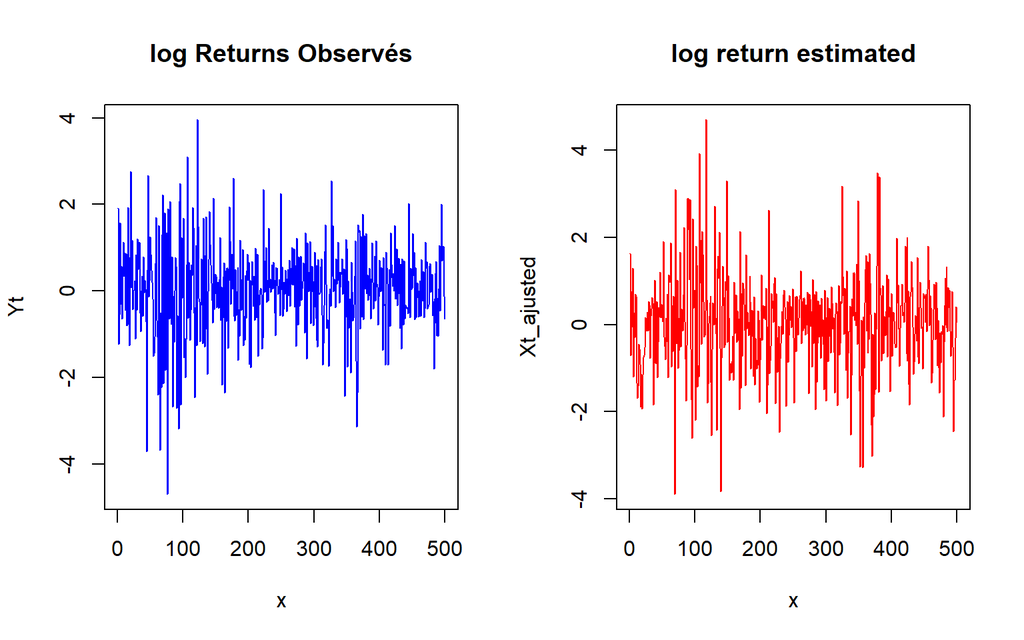

```r
x = seq(1, length(Yt))

eps = rnorm(500,0,1)
Xt_ajusted = eps*exp((Vol_particle$xHatFiltered)/2)

par(mfrow=c(1,2))
plot.ts(y = Yt, x = x, type = "l" ,main = "log Returns Observés", col = "blue")
plot.ts(y = Xt_ajusted, x = x, type = "l" ,main = "log return estimated", col = "red")
```

```r
par(mfrow=c(1,1))
```

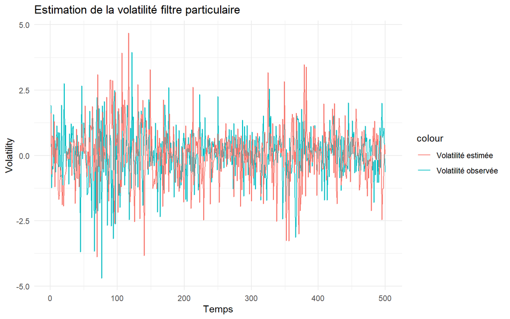

```r
data_volatility <- data.frame (obs = 1:length(Yt), Yt = Yt, vol_estimated = Xt_ajusted)

data_volatility %>%
  ggplot()+
  geom_line(aes(obs, Yt, col = "Volatilité observée "))+
  geom_line(aes(obs, vol_estimated, col = "Volatilité estimée"))+
  theme_minimal()+
  labs(x = "Temps",
       y = "Volatility",
       title = "Estimation de la volatilité filtre particulaire"
  )
```

Pour nous en convaincre nous allons calculer l’erreur absolue moyenne (MAE) et le pourcentage d’erreur absolue moyenne (MAPE). Ces deux statistiques nous indiquerons à quel point nos estimations de rendements s’approchent des valeurs réellement observées sur le marché.

$$MAE = \frac{1}{n} \sum_{i = 1} ^ n \left | y_i - \hat{y_i}\right |$$

$$MAPE = \frac{1}{n} \sum_{i = 1} ^ n \left | \frac{y_i - \hat{y_i}}{y_i} \right |$$

```
[1] "Moyenne YT observée =  0.0562983871090644"
```

```
[1] "Moyenne YT estimée =  0.025923517057865"
```

```
[1] "MAE (Equart Absolu Moyen) =  1.17288812184071"
```

```
[1] "MAPE (Pourcentage d'Equart Absolu Moyen) =  5.68886338613774"
```

Une autre manière de calibrer les volatilités consiste à utiliser le modèle Heston.

# 2 TP3 : Calibration Modèle d’Heston

Dans cette partie, nous estimons les volatilités observées avec le modèle d’Heston et nous comparons les résultats obtenus.

**Modèle d’Heston :**

```r
HestonCallClosedForm(lambda = 4, vbar = 0.03, eta = 0.4,
                     rho = -0.5, v0 = 0.03, r = 0.05,
                     tau = 1, S0 = 100, K = 100)
```

```
[1] 9.410405
```

## 2.2 Calibration du modèle d’Heston

Dans cette partie, nous créons un programme permmettant de calibrer le modèle d’Heston par bootstrap.

## 2.3 Comparaison des courbes

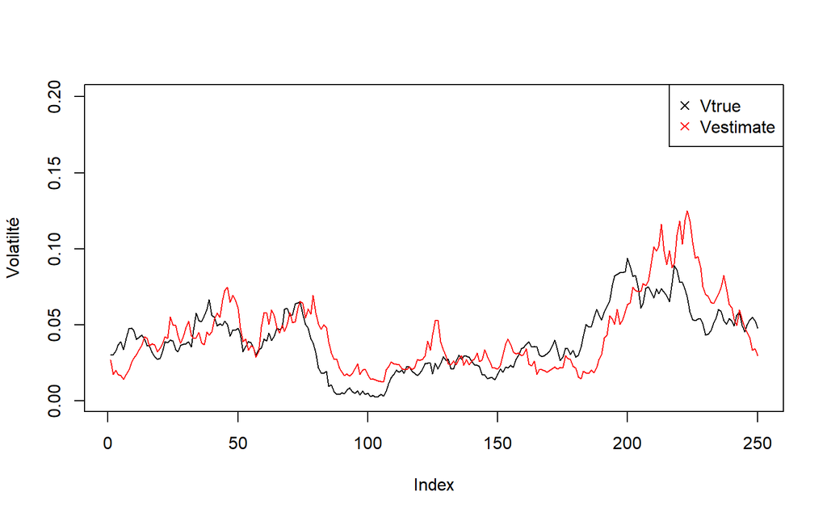

```
[1] "MAE (Equart Absolu Moyen) =  0.0133455766168498"
```

```r
par(mfrow=c(1,1))
plot(data_V$Var[1:n], type='l', ylim=c(0.001, 0.2), ylab = "Volatilté")
points(estimated_V[1:n] , type='l', col='red', ylim=c(0.001, 0.2))
legend('topright', legend=c('Vtrue', 'Vestimate'),
       col=c('black','red'), pch=4)
```

Les volatilités calibrées avec le modèle d’Heston ont la même trajectoire et sont très proches des volatités observées. Avec une erreur abolue moyenne de 0.01334558 On peut déduire que notre modèle d’Heston est bien calibré

# 3.TP4 : Modèles markoviens à changements de régime

Dans cette partie, nous allons modéliser les rendements d’un actif financier quelconque par un modèle Markovien à changement de régime

**Modèle Markovien à changement de régime :**

$$y_y = \mu S_t + \sigma S_t \epsilon_t$$

où $S_t$ représente le régime caché modélisé par une chaîne de Markov et $\epsilon_t$ un bruit gaussien centré et de variance unitaire.

**Implémentation de l’exemple :**

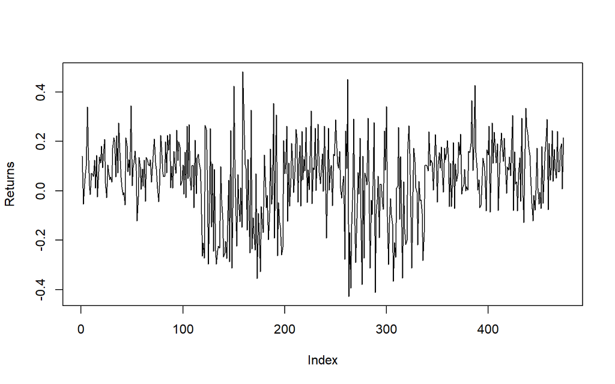

```
converged at iteration 24 with logLik: 289.6389
```

```r
plot(returns, type="l", ylab="Returns")
```

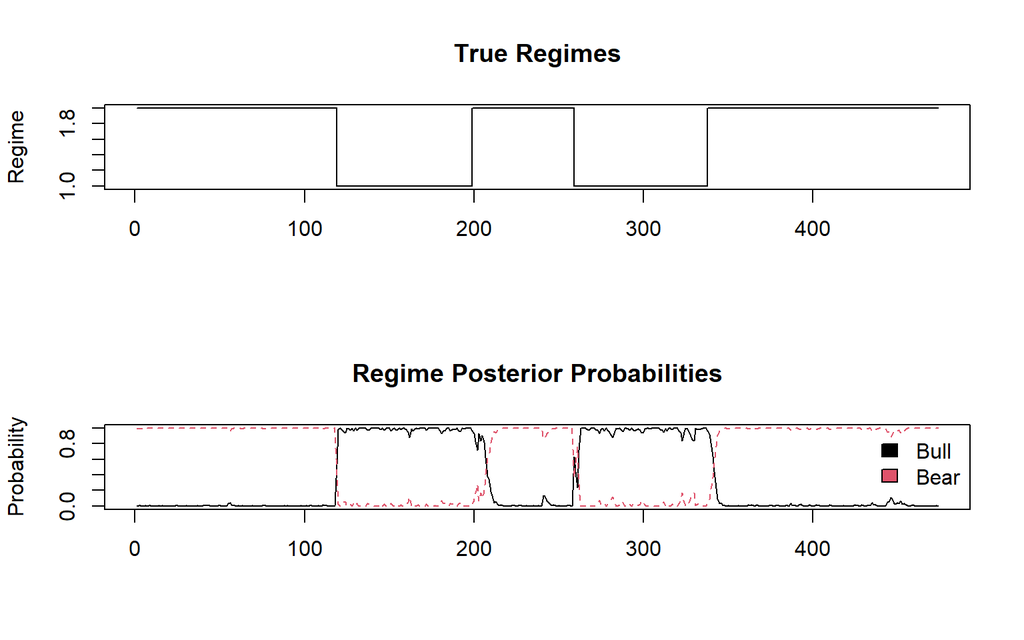

```r
layout(1:2)
plot(postprobs$state, type="s", main="True Regimes", xlab="", ylab="Regime")
matplot(postprobs[,-1], type="l", main="Regime Posterior Probabilities",
ylab="Probability")
legend(x="topright", c("Bull","Bear"), fill=1:2, bty="n")
```

## 3.2 Application sur données réelles en finance

### 3.2.1 Calcul du rendement

$$r_t = 100 \times log \left ( \frac{Y_t}{Y_{t-1}} \right )$$

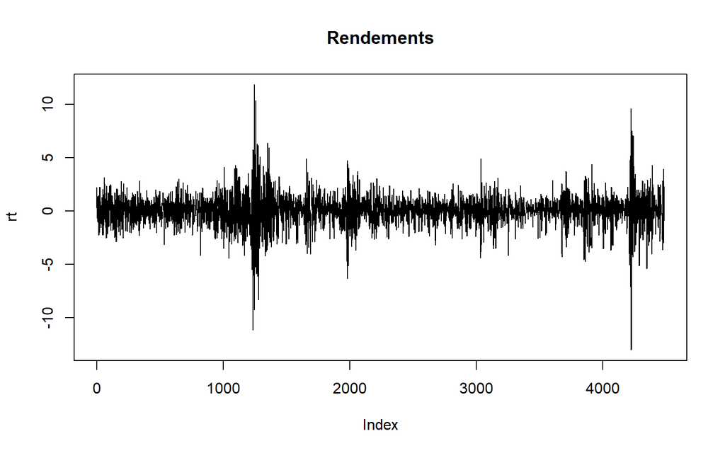

```r
rt <- 100*diff(log(NASDAQ$NASDAQ100))

plot(rt, type = "l", main = "Rendements")
```

Le graphique ci-dessus présente les log-rendements du NASDAQ du 02/01/2004 au 12/03/2021. On remarque deux périodes de grandes volatilités. La première entre 2007-2008 est dûe à la [crise des subprimes](https://fr.wikipedia.org/wiki/Crise_des_subprimes), une crise financière qui a touché le secteur des prêts hypothécaires dans le monde entier. Et la seconde qui commence en Février 2020 est dûe à la crise sanitaire liée au COVID-19.

### 2 Ajustement des modèles à Markov cachés

Au vu du graphe, il semble y avoir des périodes de grandes volatilité, et de faible volatilité et d’autres ou la volatilité semble moyenne. Quelle hypothèse est la plus plausible :

1. On a des périodes de grandes et de faibles volatilités ; auquel cas on aurait un modèle à deux état.
2. On a des périodes de grandes, de faibles et de volatilité moyennes ; auquel cas on aurait un modèle à trois états.

Estimons pour n = 2, un modèle à deux états.

```
converged at iteration 57 with logLik: -6496.524
```

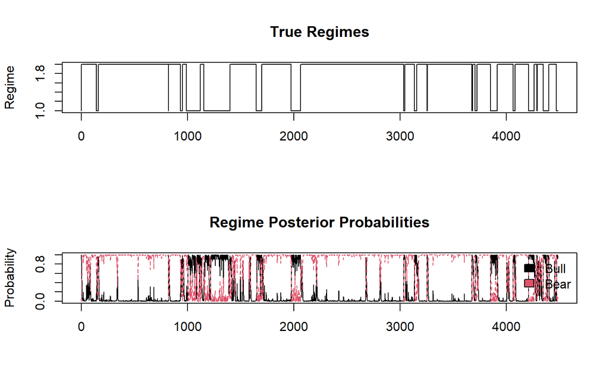

```r
layout(1:2)
plot(postprobs2$state, type="s", main="True Regimes", xlab="", ylab="Regime")
matplot(postprobs2[,-1], type="l", main="Regime Posterior Probabilities",
ylab="Probability")
legend(x="topright", c("Bull","Bear"), fill=1:2, bty="n")
```

L’estimation d’un modèle à deux états, indique que nous avons des périodes de grandes volatilités en 2007-2008 (1000-2000 sur le graphique) correspondant à la crise des subprimes et après de 2020 (4000) correspondant à la crise du COVID.entre 2010 et 2017 (2000-3000) on une période de faible volatilité. Ce qui est en parfait adéquation avec le graphique des log-rendements ci-dessus présenté.

```
converged at iteration 204 with logLik: -6349.662
```

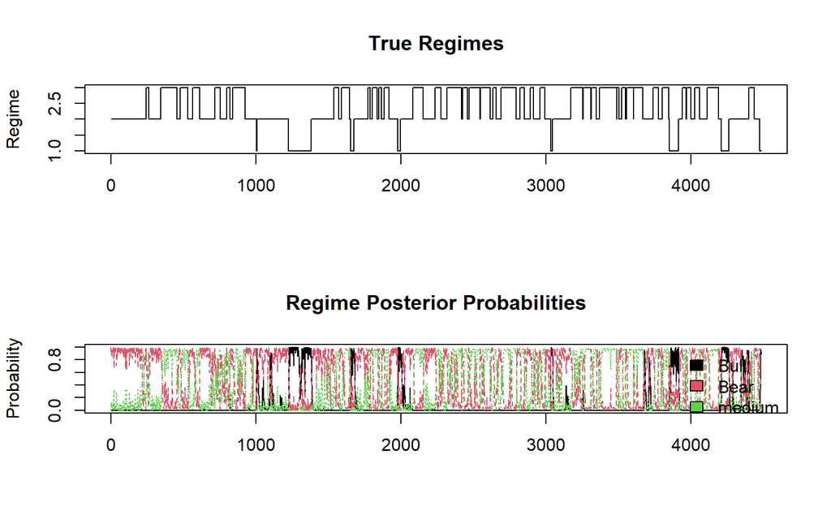

```r
layout(1:2)
plot(postprobs3$state, type="s", main="True Regimes", xlab="", ylab="Regime")
matplot(postprobs3[,-1], type="l", main="Regime Posterior Probabilities",
ylab="Probability")
legend(x="topright", c("Bull","Bear", "medium"), fill=1:3, bty="n")
```

Afin de déterminer le meilleur modèle, nous allons comparer les deux modèles en termes du BIC.

```
[1] "BIC modèle à 2 états : 15495.7107914514"
```

```
[1] "BIC modèle à 3 états : 15554.0621691108"
```

Il en ressort que le modèle a deux états a un meilleur BIC que celui à trois états. Dans le cadre de l’utilisation d’un modèle Markovien à changement de régime, on privilègera donc un modèle à deux régimes (fortes et faibles volatilité) pour calibrer la volatilité.